# FIT5215: Deep Learning (2023)

*CE/Lecturer:* Dr **Trung Le** | trunglm@monash.edu  
*Head Tutor:* Mr **Tuan Nguyen** | tuan.Ng@monash.edu  
Department of Data Science and AI, Faculty of Information Technology, Monash University, Australia

# Student Information

Surname: **NG**  
Firstname: **YI JIE**  
Student ID: **31158145**  
Email: **yngg0039@student.monash.edu**  
Your tutorial time: **Monday 10:00am to 12:00pm**

# Deep Neural Networks

### Due: 11:59pm Sunday, 10 September 2023 (Sunday)

#### Important note: This is an **individual** assignment. It contributes **20%** to your final mark. Read the assignment instruction carefully.

## Instruction

This notebook has been prepared for you to complete Assignment 1. The theme of this assignment is about practical knowledge and skills in deep neural networks, including feedforward and convolutional neural networks. Some sections have been partially completed to help you get started. **The total marks for this notebook is 100**.

- Before getting started, you should read the entire notebook carefully once to understand what you need to do.
- For each cell marked with **#YOU ARE REQUIRED TO INSERT YOUR CODES IN THIS CELL**, there will be places where you **must** supply your own codes when instructed.

This assignment contains **three** parts:

- **Part 1**: Questions on theory and knowledge on deep learning **[35 points], 35%**
- **Part 2**: Coding assessment on TensorFlow for Deep Neural Networks (DNN) **[25 points], 25%**
- **Part 3**: Coding assessment on TensorFlow for Convolution Neural Networks (CNN) **[40 points], 40%**

**Hint**: This assignment was essentially designed based on the lectures and tutorials sessions covered from Week 1 to Week 5. You are strongly recommended to go through these contents thoroughly which might help you to complete this assignment.

## What to submit

This assignment is to be completed individually and submitted to Moodle unit site. **By the due date, you are required to submit one single zip file, named xxx_assignment01_solution.zip where `xxx` is your student ID, to the corresponding Assignment (Dropbox) in Moodle**.

*For example, if your student ID is 12356, then gather all of your assignment solution to folder, create a zip file named 123456_assignment01_solution.zip and submit this file.*

Within this zip folder, you **must** submit the following files:

1. **Assignment01_solution.ipynb**: this is your Python notebook solution source file.
2. **Assignment01_output.html**: this is the output of your Python notebook solution *exported* in html format.
3. Any **extra files or folder** needed to complete your assignment (e.g., images used in your answers).

Since the notebook is quite big to load and work together, one recommended option is to split solution into three parts and work on them seperately. In that case, replace **Assignment01_solution.ipynb** by three notebooks: **Assignment01_Part1_solution.ipynb**, **Assignment01_Part2_solution.ipynb** and **Assignment01_Part3_solution.ipynb**

**You can run your codes on Google Colab. In this case, you have to make a copy of your Google colab notebook including the traces and progresses of model training before submitting.**

You also need to store your trained models to folder *./models* with recognizable file names (e.g., Part3_Sec3_2_model.h5).

## Part 3: Convolutional Neural Networks and Image Classification

[Total marks for this part: 40 points]

**This part of the asssignment is designed to assess your knowledge and coding skill with Tensorflow as well as hands-on experience with training Convolutional Neural Network (CNN).**

**The dataset used for this part is a specific dataset for this unit consisting of approximately $10,000$ images of $20$ classes, each of which has approximately 500 images. You can download the dataset at [download here](https://drive.google.com/file/d/1eURMjyUROowKeh5hKJPpZCLg7ne625fF/view?usp=sharing) and then decompress to the folder `datasets\FIT5215_Dataset` in your assignment folder.**

**Your task is to build a CNN model using *TF 2.x* to classify the images. You're provided with the module models.py, which you can find in the assignment folder, with some of the following classes:**

1. `DatasetManager`: Support with loading and spliting the dataset into the train-val-test sets. It also supports generating next batches for training. `DatasetManager` will be passed to CNN model for training and testing.
2. `DefaultModel`: A base class for the CNN model.
3. `YourModel`: The class you'll need to implement for building your CNN model. It inherits some useful attributes and functions from the base class `DefaultModel`
4. Note that you can freely modify the `models.py` file for your purposes.

Firstly, we need to run the following cells to load and preprocess the FIT5215 dataset.

```python
%load_ext autoreload
%autoreload 2
```

Install the package `imutils` if you have not installed yet

```python
! pip install imutils
```

```python
import os
import matplotlib.pyplot as plt
plt.style.use('ggplot')
%matplotlib inline
import models
from models import SimplePreprocessor, DatasetManager, DefaultModel
```

```python
def create_label_folder_dict(adir):
    sub_folders= [folder for folder in os.listdir(adir)
                  if os.path.isdir(os.path.join(adir, folder))]
    label_folder_dict= dict()
    for folder in sub_folders:
        item= {folder: os.path.abspath(os.path.join(adir, folder))}
        label_folder_dict.update(item)
    return label_folder_dict
```

```python
label_folder_dict= create_label_folder_dict("./datasets/FIT5215_Dataset")
```

The below code helps to create a data manager that contains all relevant methods used to manage and process the experimental data.

```python
sp = SimplePreprocessor(width=32, height=32)
data_manager = DatasetManager([sp])
data_manager.load(label_folder_dict, verbose=100)
data_manager.process_data_label()
data_manager.train_valid_test_split()
```

```
birds 484
Processed 100/500
Processed 200/500
Processed 300/500
Processed 400/500
bottles 432
Processed 100/500
Processed 200/500
Processed 300/500
Processed 400/500
breads 432
Processed 100/500
Processed 200/500
Processed 300/500
Processed 400/500
butterfiles 500
Processed 100/500
Processed 200/500
Processed 300/500
Processed 400/500
Processed 500/500
cakes 432
Processed 100/500
Processed 200/500
Processed 300/500
Processed 400/500
cats 501
Processed 100/500
Processed 200/500
Processed 300/500
Processed 400/500
Processed 500/500
chickens 500
Processed 100/500
Processed 200/500
Processed 300/500
Processed 400/500
Processed 500/500
cows 500
Processed 100/500
```

[output cut: 54 more lines]

```
snakes 496
Processed 100/500
Processed 200/500
Processed 300/500
Processed 400/500
spiders 500
Processed 100/500
Processed 200/500
Processed 300/500
Processed 400/500
Processed 500/500
vases 368
Processed 100/500
Processed 200/500
Processed 300/500
```

Note that the object `data_manager` has the attributes relating to *the training, validation, and testing sets* as shown belows. You can use them in training your developped models in the sequel.

```python
print(data_manager.X_train.shape, data_manager.y_train.shape)
print(data_manager.X_valid.shape, data_manager.y_valid.shape)
print(data_manager.X_test.shape, data_manager.y_test.shape)
print(data_manager.classes)
```

```
(7548, 32, 32, 3) (7548,)
(944, 32, 32, 3) (944,)
(944, 32, 32, 3) (944,)
['birds' 'bottles' 'breads' 'butterfiles' 'cakes' 'cats' 'chickens' 'cows'
 'dogs' 'ducks' 'elephants' 'fishes' 'handguns' 'horses' 'lions'
 'lipsticks' 'seals' 'snakes' 'spiders' 'vases']
```

We now run the **default model** built in the **models.py** file which serves as a basic baseline to start the investigation. Follow the following steps to realize how to run a model and know the built-in methods associated to a model developped in the DefaultModel class.

We first initialize a default model from the DefaultModel class. Basically, we can define the relevant parameters of training a model including `num_classes`, `optimizer`, `learning_rate`, `batch_size`, and `num_epochs`.

```python
network1 = DefaultModel(name='network1',
                       num_classes=len(data_manager.classes),
                       optimizer='sgd',
                       batch_size= 128,
                       num_epochs = 20,
                       learning_rate=0.1)
```

The method `build_cnn()` assists us in building your convolutional neural network. You can view the code (in the **models.py** file) of the model behind a default model to realize how simple it is. Additionally, the method `summary()` shows the architecture of a model.

```python
network1.build_cnn()
network1.summary()
```

```
Model: "sequential_1"
_________________________________________________________________
 Layer (type)                Output Shape              Param #
=================================================================
 conv2d (Conv2D)             (None, 32, 32, 32)        896

 conv2d_1 (Conv2D)           (None, 32, 32, 32)        9248

 average_pooling2d (AverageP  (None, 16, 16, 32)       0
 ooling2D)

 conv2d_2 (Conv2D)           (None, 16, 16, 64)        18496

 conv2d_3 (Conv2D)           (None, 16, 16, 64)        36928

 average_pooling2d_1 (Averag  (None, 8, 8, 64)         0
 ePooling2D)

 flatten (Flatten)           (None, 4096)              0

 dense (Dense)               (None, 20)                81940

=================================================================
Total params: 147,508
Trainable params: 147,508
Non-trainable params: 0
_________________________________________________________________
None
```

To train a model regarding to the datasets stored in `data_manager`, you can invoke the method `fit()` for which you can specify the batch size and number of epochs for your training.

```python
network1.fit(data_manager, batch_size = 64, num_epochs = 20)
```

Here you can compute the accuracy of your trained model with respect to a separate testing set.

```python
network1.compute_accuracy(data_manager.X_test, data_manager.y_test)
```

```
0.3792372941970825
```

Below shows how you can inspect the training progress.

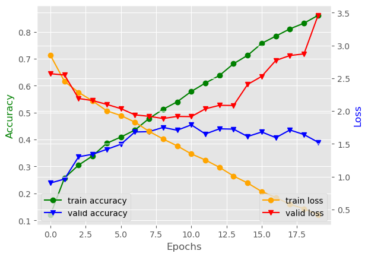

```python
network1.plot_progress()
```

You can use the method `predict()` to predict labels for data examples in a test set.

```python
network1.predict(data_manager.X_test[0:10])
```

```
array([15,  5, 18,  8, 10,  5, 14, 10,  5,  5], dtype=int64)
```

Finally, the method `plot_prediction()` visualizes the predictions for a test set in which several images are chosen to show the predictions.

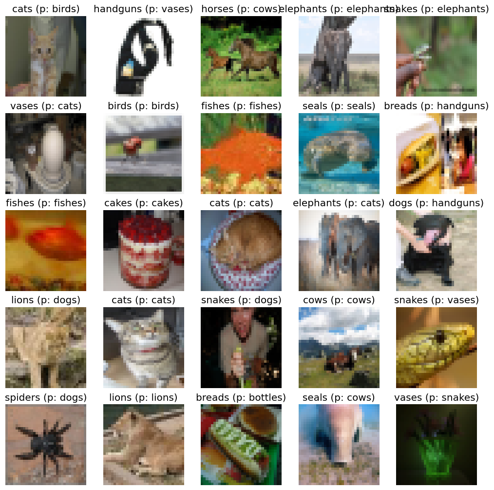

```python
network1.plot_prediction(data_manager.X_test, data_manager.y_test, data_manager.classes)
```

**For questions 3.1 to 3.7, you'll need to write your own model in a way that makes it easy for you to experiment with different architectures and parameters. The goal is to be able to pass the parameters to initialize a new instance of `YourModel` to build different network architectures with different parameters. Below are descriptions of some parameters for `YourModel`:**

1. `Block architecture`: Each block has the pattern `[conv, batch norm, activation, conv, batch norm, activation, mean pool]`. All convolutional layers have filter size $(3, 3)$, strides $(1, 1)$ and 'SAME' padding, and all mean pool layers have strides $(2, 2)$ and 'SAME' padding. The network will consists of a few blocks before applying a `global average pooling (GAP)` layer to obtain vectors and then a dense layer to output the logits for the softmax layer.

When designing a block, there must have some instance variables as follows

1. `num_channels`: the number of channels used in a block, which will be applied to two Convs in the block.
2. `mean_pool (True, False)`: the mean pool is used not. If `mean_pool = True`, it is used to downsample the input by two.
3. `batch_norm (True, False)`: the batch normalization function is used or not. Setting `batch_norm` to `False` means not using batch normalization.
4. The `skip connection (True, False)` is added to the output of the second `batch norm`. Additionally, your class has a boolean property (i.e., instance variable) named `use_skip`. If `use_skip=True`, the skip connectnion is enable. Otherwise, if `use_skip=False`, the skip connectnion is disable.

Below is the architecture of one block:

[figure not shown]

Below is the architecture of the entire deep net with `two blocks`:

[figure not shown]

The above network has two blocks with the numbers of channels are 16 and 32 respectively. We apply a global average pooling (GAP) layer to flattern the output of the last block, followed by an output layer for prediction.

```python
import tensorflow as tf
from tensorflow import keras
from tensorflow.keras import layers, models
```

```python
tf.random.set_seed(31158145)
```

**Question 3.1** **Write the code of the `YourModel` class here. Note that this class will inherit from the `DefaultModel` class. You'll only need to re-write the code for the `build_cnn` method in the `YourModel` class from the cell below. Note that the `YourModel` class is inherited from the `DefaultModel` class.**

[6 points]

```python
import numpy as np
from keras.models import Model

class YourModel(DefaultModel):
    def __init__(self, name='network1', width = 32, height = 32, depth = 3, num_classes = 20, is_augmentation = False,
                 activation_func = 'relu', optimizer='adam', batch_size=32, num_epochs= 20, learning_rate=0.001,
                 verbose= True):
        super(YourModel, self).__init__(name, width, height, depth, num_classes, is_augmentation,
                                        activation_func, optimizer, batch_size, num_epochs,
                                        learning_rate, verbose)

        # initialisation for paramters of the class
        self.num_classes = num_classes
        self.activation_func = activation_func
        self.is_augmentation = False
        self.batch_size = batch_size
        self.num_epochs = num_epochs
        self.learning_rate = learning_rate
        self.verbose= verbose


    # cnn layer which build a basic layer of CNN blocks by blocks
    def cnn_layer(self):
        x = self.input_layer
        for l in range(self.num_blocks):
            input_org = x
            self.num_channels *= 2
            s = self.num_channels
            # conv 2d
            x = (layers.Conv2D(self.num_channels, (3,3), strides = self.strides, padding='same'))(x)
            # batch norm
            if self.batch_norm:
                x = layers.BatchNormalization()(x)
            # activation
            x = layers.Activation(self.activation_func)(x)
            # conv 2d
            x = (layers.Conv2D(self.num_channels, (3,3), strides = self.strides, padding='same'))(x)
            # batch norm
            if self.batch_norm:
                x = layers.BatchNormalization()(x)


            # Code for necessary action when used_skip
            if self.used_skip:
                desired_channels = s
                channels_to_add = desired_channels - input_org.shape[-1]

                # Check if channels need to be added
                if channels_to_add > 0:
                    # Create a tensor of zeros with the desired shape
                    zero_channels = tf.zeros((tf.shape(input_org)[0], tf.shape(input_org)[1], tf.shape(input_org)[2], channels_to_add))

                    # Concatenate the zero-initialized channels to the input tensor
                    padded_tensor = tf.keras.layers.Concatenate(axis=-1)([input_org, zero_channels])

                else:
                    # No padding needed, keep the input tensor as is
                    padded_tensor = input_org

                x = keras.layers.add([x, padded_tensor])

            # activation
            x = layers.Activation(self.activation_func)(x)
            if self.mean_pool:
                # mean pooling
                x = layers.AveragePooling2D(pool_size=(2, 2), padding='same')(x)
        return x


    def cnn(self, strides=1, num_channels = 16, num_blocks = 16, mean_pool=True, batch_norm=True, used_skip=True,
             num_classes=20, batch_size = 32):
        # initialisation for parameters
        input_data = data_manager.next_batch(batch_size = batch_size)
        self.strides = strides
        self.num_channels = num_channels
        self.mean_pool = mean_pool
        self.batch_norm = batch_norm
        self.used_skip = used_skip
        self.input_data = input_data[0]
        self.num_classes = num_classes
        self.used_skip = used_skip
        self.num_blocks = num_blocks
        # set up the input layer
        self.width = self.input_data.shape[1]
        self.height = self.input_data.shape[2]
        self.depth = self.input_data.shape[3]

        self.input_layer = layers.Input(shape = (self.width,self.height,self.depth))

        # cnn layer
        x1 = self.cnn_layer()
        return x1


    def build_cnn(self, num_channels, num_blocks, batch_norm, use_skip, mean_pool, batch_size):
        #Insert your code here
        x1 = self.cnn(num_blocks = num_blocks, num_channels = num_channels, mean_pool=mean_pool,
                                batch_norm=batch_norm, used_skip=use_skip, batch_size = batch_size)

        # last layer of whole cnn model which flat and dense
        x1 = layers.GlobalAvgPool2D()(x1)
        y1 = layers.Flatten()(x1)
        output = layers.Dense(self.num_classes, activation='softmax')(y1)
        # Instantiate model
        self.model = tf.keras.models.Model(inputs=self.input_layer, outputs=output)
        self.model.compile(optimizer=self.optimizer, loss='sparse_categorical_crossentropy', metrics=['accuracy'])
```

Now run your model with a specific configuration.

```python
#Your run here
my_cnn_model = YourModel(learning_rate = 0.001)

my_cnn_model.build_cnn(num_channels = 16, num_blocks = 2, mean_pool=True, batch_norm=True,
                     use_skip=True, batch_size = 16)
my_cnn_model.summary()
my_cnn_model.fit(data_manager, batch_size = 16, num_epochs=20)
```

```
Model: "model"
__________________________________________________________________________________________________
 Layer (type)                   Output Shape         Param #     Connected to
==================================================================================================
 input_1 (InputLayer)           [(None, 32, 32, 3)]  0           []

 conv2d_4 (Conv2D)              (None, 32, 32, 32)   896         ['input_1[0][0]']

 batch_normalization (BatchNorm  (None, 32, 32, 32)  128         ['conv2d_4[0][0]']
 alization)

 tf.compat.v1.shape (TFOpLambda  (4,)                0           ['input_1[0][0]']
 )

 tf.compat.v1.shape_1 (TFOpLamb  (4,)                0           ['input_1[0][0]']
 da)

 tf.compat.v1.shape_2 (TFOpLamb  (4,)                0           ['input_1[0][0]']
 da)

 activation (Activation)        (None, 32, 32, 32)   0           ['batch_normalization[0][0]']

 tf.__operators__.getitem (Slic  ()                  0           ['tf.compat.v1.shape[0][0]']
 ingOpLambda)

 tf.__operators__.getitem_1 (Sl  ()                  0           ['tf.compat.v1.shape_1[0][0]']
 icingOpLambda)

 tf.__operators__.getitem_2 (Sl  ()                  0           ['tf.compat.v1.shape_2[0][0]']
 icingOpLambda)

 conv2d_5 (Conv2D)              (None, 32, 32, 32)   9248        ['activation[0][0]']

 tf.zeros (TFOpLambda)          (None, 32, 32, 29)   0           ['tf.__operators__.getitem[0][0]'
                                                                 , 'tf.__operators__.getitem_1[0][
                                                                 0]',
                                                                  'tf.__operators__.getitem_2[0][0
                                                                 ]']

 batch_normalization_1 (BatchNo  (None, 32, 32, 32)  128         ['conv2d_5[0][0]']
```

[output cut: 60 more lines]

```

 global_average_pooling2d (Glob  (None, 64)          0           ['average_pooling2d_3[0][0]']
 alAveragePooling2D)

 flatten_1 (Flatten)            (None, 64)           0           ['global_average_pooling2d[0][0]'
                                                                 ]

 dense_1 (Dense)                (None, 20)           1300        ['flatten_1[0][0]']

==================================================================================================
Total params: 67,636
Trainable params: 67,252
Non-trainable params: 384
__________________________________________________________________________________________________
None
```

**Question 3.2** **Now, let us tune the number of blocks $num\_blocks \in \{3,4\}$, $use\_skip \in \{True, False\}$, $mean\_pool \in \{True, False\}$, and $learning\_rate \in \{0.001, 0.0001\}$. Write your code for this tuning and report the result of the best model on the testing set. Note that you need to show your code for tuning and evaluating on the test set to earn the full marks. During tuning, you can set the instance variable `verbose` of your model to `False` for not showing the training details of each epoch.**

[4 points]

# *Report the best parameters and the testing accuracy here*

Best parameters: num_blocks = 4, use_skip = True, mean_pool = True, learning_rate = 0.001

```
Train Accuracy: 0.9512
Valid accuracy: 0.5847
Test Accuracy : 0.5572
```

```python
#Insert your code here. You can add more cells if necessary
num_blocks = [3,4]
use_skip = [True, False]
mean_pool = [True, False]
learning_rate = [0.001, 0.0001]
best_accuracy = 0
best_parameters = []
# the code to loop and run through all the combination is commented to save the time.
# The final best parameter is 4 True True 0.001

# For loop to find the best parameter from the combination.
# for w in num_blocks:
#     for x in use_skip:
#         for y in mean_pool:
#             for z in learning_rate:
#                 print("==============================================")
#                 print("Parameter(num_blocks, use_skip, mean_pool, learning_rate) :", w,x,y,z)
#                 my_network = YourModel(learning_rate=z, verbose= False)
#                 my_network.build_cnn(num_channels = 16, num_blocks = w, mean_pool=y, batch_norm=True,
#                                      use_skip=x, batch_size = 16)
#                 my_network.fit(data_manager, batch_size = 16, num_epochs=20)
#                 acc = my_network.compute_accuracy(data_manager.X_test, data_manager.y_test, batch_size = 16)
#                 print()
#                 if acc > best_accuracy:
#                     best_accuracy = acc
#                     best_parameters = [w,x,y,z]
#                 print("{} (num_blocks, use_skip, mean_pool, learning_rate) is the best paramter currently with accuracy of {}".format(best_parameters, best_accuracy))

my_network = YourModel(learning_rate=0.001, verbose= True)
my_network.build_cnn(num_channels = 16, num_blocks = 4, mean_pool=True, batch_norm=True,
                     use_skip=True, batch_size = 16)
my_network.fit(data_manager, batch_size = 16, num_epochs=20)
my_network.compute_accuracy(data_manager.X_test, data_manager.y_test, batch_size = 16)
```

```
0.5572034120559692
```

```python
# print("The best parameter is {} (num_blocks, use_skip, mean_pool, learning_rate) with accuracy of {}".format(best_parameters, best_accuracy))
```

**Question 3.3** **We now try to apply data augmentation to improve the performance. Extend the code of the class `YourModel` so that if the attribute `is_augmentation` is set to `True`, we apply the data augmentation. Also you need to incorporate early stopping to your training process. Specifically, you early stop the training if the valid accuracy cannot increase in three consecutive epochs.**

[4 points]

```python
from tensorflow.keras.preprocessing.image import ImageDataGenerator
from tensorflow.keras.callbacks import EarlyStopping
```

Wtire your code in the cell below. Hint that you can rewrite the code of the `fit` method to apply the data augmentation. In addition, you can copy the code of `build_cnn` method above to reuse here.

```python
class YourModel(DefaultModel):
    def __init__(self, name='network1', width = 32, height = 32, depth = 3, num_classes = 20, is_augmentation = False,
                 activation_func = 'relu', optimizer='adam', batch_size=32, num_epochs= 20, learning_rate=0.001,
                 verbose= True):
        super(YourModel, self).__init__(name, width, height, depth, num_classes, is_augmentation,
                                        activation_func, optimizer, batch_size, num_epochs,
                                        learning_rate, verbose)

        # initialisation for paramters of the class
        self.num_classes = num_classes
        self.activation_func = activation_func
        self.is_augmentation = is_augmentation
        self.batch_size = batch_size
        self.num_epochs = num_epochs
        self.learning_rate = learning_rate
        self.verbose= verbose


    # cnn layer which build a basic layer of CNN blocks by blocks
    def cnn_layer(self):
        x = self.input_layer
        for l in range(self.num_blocks):
            input_org = x
            self.num_channels *= 2
            s = self.num_channels
            # conv 2d
            x = (layers.Conv2D(self.num_channels, (3,3), strides = self.strides, padding='same'))(x)
            # batch norm
            if self.batch_norm:
                x = layers.BatchNormalization()(x)
            # activation
            x = layers.Activation(self.activation_func)(x)
            # conv 2d
            x = (layers.Conv2D(self.num_channels, (3,3), strides = self.strides, padding='same'))(x)
            # batch norm
            if self.batch_norm:
                x = layers.BatchNormalization()(x)


            # Code for necessary action when used_skip
            if self.used_skip:
                desired_channels = s
                channels_to_add = desired_channels - input_org.shape[-1]

                # Check if channels need to be added
                if channels_to_add > 0:
                    # Create a tensor of zeros with the desired shape
                    zero_channels = tf.zeros((tf.shape(input_org)[0], tf.shape(input_org)[1], tf.shape(input_org)[2], channels_to_add))

                    # Concatenate the zero-initialized channels to the input tensor
                    padded_tensor = tf.keras.layers.Concatenate(axis=-1)([input_org, zero_channels])

                else:
                    # No padding needed, keep the input tensor as is
                    padded_tensor = input_org

                x = keras.layers.add([x, padded_tensor])

            # activation
            x = layers.Activation(self.activation_func)(x)
            if self.mean_pool:
                # mean pooling
                x = layers.AveragePooling2D(pool_size=(2, 2), padding='same')(x)
        return x


    def cnn(self, strides=1, num_channels = 16, num_blocks = 16, mean_pool=True, batch_norm=True, used_skip=True,
             num_classes=20, batch_size = 32):
        # initialisation for parameters
        input_data = data_manager.next_batch(batch_size = batch_size)
        self.strides = strides
        self.num_channels = num_channels
        self.mean_pool = mean_pool
        self.batch_norm = batch_norm
        self.used_skip = used_skip
        self.input_data = input_data[0]
        self.num_classes = num_classes
        self.used_skip = used_skip
        self.num_blocks = num_blocks
        # set up the input layer
        self.width = self.input_data.shape[1]
        self.height = self.input_data.shape[2]
        self.depth = self.input_data.shape[3]

        self.input_layer = layers.Input(shape = (self.width,self.height,self.depth))

        # cnn layer
        x1 = self.cnn_layer()
        return x1


    def build_cnn(self, num_channels, num_blocks, batch_norm, use_skip, mean_pool, batch_size):
        #Insert your code here
        x1 = self.cnn(num_blocks = num_blocks, num_channels = num_channels, mean_pool=mean_pool,
                                batch_norm=batch_norm, used_skip=use_skip, batch_size = batch_size)

        # last layer of whole cnn model which flat and dense
        x1 = layers.GlobalAvgPool2D()(x1)
        y1 = layers.Flatten()(x1)
        output = layers.Dense(self.num_classes, activation='softmax')(y1)
        # Instantiate model
        self.model = tf.keras.models.Model(inputs=self.input_layer, outputs=output)


    def fit(self, data_manager, batch_size=None, num_epochs=None):
        #Insert your code here
        batch_size = self.batch_size if batch_size is None else batch_size
        num_epochs = self.num_epochs if num_epochs is None else num_epochs

        # early stopping
        early_stopping = EarlyStopping(monitor='val_accuracy', patience=3, restore_best_weights=True)

        # data augmentation
        if self.is_augmentation:
            # augmentate the data
            datagen = ImageDataGenerator(horizontal_flip=True, width_shift_range=0.1, height_shift_range=0.1)
            datagen.fit(data_manager.X_train)
            augmented_data = datagen.flow(data_manager.X_train, data_manager.y_train, batch_size=batch_size)
            self.model.compile(optimizer=self.optimizer, loss='sparse_categorical_crossentropy', metrics=['accuracy'])
            # fit the augmentated data
            self.history = self.model.fit(augmented_data, validation_data = (data_manager.X_valid, data_manager.y_valid),
                                          epochs = num_epochs, batch_size = batch_size, verbose= self.verbose,
                                          callbacks = [early_stopping])

        else:
            batch_size = self.batch_size if batch_size is None else batch_size
            num_epochs = self.num_epochs if num_epochs is None else num_epochs
            self.model.compile(optimizer=self.optimizer, loss='sparse_categorical_crossentropy', metrics=['accuracy'])
            self.history = self.model.fit(x = data_manager.X_train, y = data_manager.y_train,
                                          validation_data = (data_manager.X_valid, data_manager.y_valid),
                                          epochs = num_epochs, batch_size = batch_size, verbose= self.verbose,
                                          callbacks = [early_stopping])
```

Leverage your best model with the data augmentation and try to observe the difference in performance between using data augmentation and non-using it.

# *Write your answer and observation here*

Parameters: num_blocks = 4, use_skip = True, mean_pool = True, learning_rate = 0.001

Other parameters: batch_size = 16, num_epochs = 20

**Without data augmentation**

```
Train Accuracy: 0.9512
Valid accuracy: 0.5847
Test Accuracy : 0.5572
```

**With data augmentation**

```
Train Accuracy: 0.7699
Valid accuracy: 0.6335
Test Accuracy : 0.6282
```

We can observe that higher Train accuracy occurs **without using data augmentation** but having lower Valid and Test Accuracy. This is because without data augmentation, model will brute force try to memorise the pattern which often called overfitting. To overcome the issue, data augmentation augmentate the pattern to avoid the overfitting behaviour which return higher valid and test accuracy but lower train accuracy.

```python
#Insert your code here. You can add more cells if necessary
my_cnn_model = YourModel(learning_rate = 0.001, is_augmentation = True)

my_cnn_model.build_cnn(num_channels = 16, num_blocks = 4, mean_pool=True, batch_norm=True,
                     use_skip=True, batch_size = 16)
my_cnn_model.fit(data_manager, batch_size = 16, num_epochs=20)
my_cnn_model.compute_accuracy(data_manager.X_test, data_manager.y_test, batch_size = 16)
```

```
0.6281779408454895
```

**Question 3.4** **Exploring Data Mixup Technique for Improving Generalization Ability.**

[4 points]

Data mixup is another super-simple technique used to boost the generalization ability of deep learning models. You need to incoroporate data mixup technique to the above deep learning model and experiment its performance. There are some papers and documents for data mixup as follows:

- Main paper for data mixup [link for main paper](https://openreview.net/pdf?id=r1Ddp1-Rb) and a good article [article link](https://www.inference.vc/mixup-data-dependent-data-augmentation/).

You need to extend your model developed above, train a model using data mixup, and write your observations and comments about the result.

# *Write your answer and observation here*

Parameters: num_blocks = 4, use_skip = True, mean_pool = True, learning_rate = 0.001

Other parameters: batch_size = 16, num_epochs = 20, data_augmentation = True

**Without data mixup**

```
Train Accuracy: 0.7699
Valid accuracy: 0.6335
Test Accuracy : 0.6282
```

**With data mixup**

```
Train Accuracy: 0.8721
Valid accuracy: 0.6864
Test Accuracy : 0.6663
```

With data mixup, we have higher train, valid and test accuracy. THis is because we add in more mixed data to train, generalise and reduce noise of inputs. Therefore it enhance the performances of the model

```python
#Insert your code here. You can add more cells if necessary
class YourModel(DefaultModel):
    def __init__(self, name='network1', width = 32, height = 32, depth = 3, num_classes = 20, is_augmentation = False,
                 activation_func = 'relu', optimizer='adam', batch_size=32, num_epochs= 20, learning_rate=0.001,
                 verbose= True):
        super(YourModel, self).__init__(name, width, height, depth, num_classes, is_augmentation,
                                        activation_func, optimizer, batch_size, num_epochs,
                                        learning_rate, verbose)

        # initialisation for paramters of the class
        self.num_classes = num_classes
        self.activation_func = activation_func
        self.is_augmentation = is_augmentation
        self.batch_size = batch_size
        self.num_epochs = num_epochs
        self.learning_rate = learning_rate
        self.verbose= verbose


    # cnn layer which build a basic layer of CNN blocks by blocks
    def cnn_layer(self):
        x = self.input_layer
        for l in range(self.num_blocks):
            input_org = x
            self.num_channels *= 2
            s = self.num_channels
            # conv 2d
            x = (layers.Conv2D(self.num_channels, (3,3), strides = self.strides, padding='same'))(x)
            # batch norm
            if self.batch_norm:
                x = layers.BatchNormalization()(x)
            # activation
            x = layers.Activation(self.activation_func)(x)
            # conv 2d
            x = (layers.Conv2D(self.num_channels, (3,3), strides = self.strides, padding='same'))(x)
            # batch norm
            if self.batch_norm:
                x = layers.BatchNormalization()(x)


            # Code for necessary action when used_skip
            if self.used_skip:
                desired_channels = s
                channels_to_add = desired_channels - input_org.shape[-1]

                # Check if channels need to be added
                if channels_to_add > 0:
                    # Create a tensor of zeros with the desired shape
                    zero_channels = tf.zeros((tf.shape(input_org)[0], tf.shape(input_org)[1], tf.shape(input_org)[2], channels_to_add))

                    # Concatenate the zero-initialized channels to the input tensor
                    padded_tensor = tf.keras.layers.Concatenate(axis=-1)([input_org, zero_channels])

                else:
                    # No padding needed, keep the input tensor as is
                    padded_tensor = input_org

                x = keras.layers.add([x, padded_tensor])

            # activation
            x = layers.Activation(self.activation_func)(x)
            if self.mean_pool:
                # mean pooling
                x = layers.AveragePooling2D(pool_size=(2, 2), padding='same')(x)
        return x


    def cnn(self, strides=1, num_channels = 16, num_blocks = 16, mean_pool=True, batch_norm=True, used_skip=True,
             num_classes=20, batch_size = 32):
        # initialisation for parameters
        input_data = data_manager.next_batch(batch_size = batch_size)
        self.strides = strides
        self.num_channels = num_channels
        self.mean_pool = mean_pool
        self.batch_norm = batch_norm
        self.used_skip = used_skip
        self.input_data = input_data[0]
        self.num_classes = num_classes
        self.used_skip = used_skip
        self.num_blocks = num_blocks
        # set up the input layer
        self.width = self.input_data.shape[1]
        self.height = self.input_data.shape[2]
        self.depth = self.input_data.shape[3]

        self.input_layer = layers.Input(shape = (self.width,self.height,self.depth))

        # cnn layer
        x1 = self.cnn_layer()
        return x1


    def build_cnn(self, num_channels, num_blocks, batch_norm, use_skip, mean_pool, batch_size):
        #Insert your code here
        x1 = self.cnn(num_blocks = num_blocks, num_channels = num_channels, mean_pool=mean_pool,
                                batch_norm=batch_norm, used_skip=use_skip, batch_size = batch_size)

        # last layer of whole cnn model which flat and dense
        x1 = layers.GlobalAvgPool2D()(x1)
        y1 = layers.Flatten()(x1)
        output = layers.Dense(self.num_classes, activation='softmax')(y1)
        # Instantiate model
        self.model = tf.keras.models.Model(inputs=self.input_layer, outputs=output)
        self.model.compile(optimizer=self.optimizer, loss='sparse_categorical_crossentropy', metrics=['accuracy'])

    # mix up function which follow the formula of mixed_xy = (lambda * xy) + ((1 - lambda) * xy)
    def mixup(self, x1, y1, x2, y2, alpha=0.2):
        y1 = tf.one_hot(y1, 20)
        y2 = tf.one_hot(y2, 20)
        beta = np.random.beta(alpha, alpha)
        mixed_x = (beta * x1) + ((1 - beta) * x2)
        mixed_y = (beta * y1) + ((1 - beta) * y2)
        return mixed_x, mixed_y


    def fit(self, data_manager, batch_size=None, num_epochs=None, is_augmentation = True):
        #Insert your code here
        self.is_augmentation = is_augmentation

        batch_size = self.batch_size if batch_size is None else batch_size
        num_epochs = self.num_epochs if num_epochs is None else num_epochs

        # early stopping
        early_stopping = EarlyStopping(monitor='val_accuracy', patience=3, restore_best_weights=True)

        # data mix up
        mixed_X = []
        mixed_y = []
        data_size = data_manager.X_train.shape[0]

        # loop through the dataset and mix two consecutives data
        for i in range(0,data_size,2):
            mixed_x_element, mixed_y_element = self.mixup(data_manager.X_train[i], data_manager.y_train[i], data_manager.X_train[i+1], data_manager.y_train[i+1], alpha = 0.2)
            mixed_X.append(mixed_x_element)
            mixed_y.append(mixed_y_element)

        # convert normal array to np array
        mixed_X = np.array(mixed_X)
        mixed_y = np.array(mixed_y)
        # covnert one hot vector back to normal vector for y label
        mixed_y = np.argmax(mixed_y, axis=1)
        # concatenate original train set with mixup set
        final_x = np.concatenate((data_manager.X_train, mixed_X))
        final_y = np.concatenate((data_manager.y_train, mixed_y))

        # data augmentation
        if self.is_augmentation:
            datagen = ImageDataGenerator(horizontal_flip=True, width_shift_range=0.1, height_shift_range=0.1)
            datagen.fit(final_x)
            augmented_data = datagen.flow(final_x, final_y, batch_size=batch_size)
            self.model.compile(optimizer=self.optimizer, loss='sparse_categorical_crossentropy', metrics=['accuracy'])
            self.history = self.model.fit(augmented_data, validation_data = (data_manager.X_valid, data_manager.y_valid),
                                          epochs = num_epochs, batch_size = batch_size, verbose= self.verbose,
                                          callbacks = [early_stopping])

        else:
            batch_size = self.batch_size if batch_size is None else batch_size
            num_epochs = self.num_epochs if num_epochs is None else num_epochs
            self.model.compile(optimizer=self.optimizer, loss='sparse_categorical_crossentropy', metrics=['accuracy'])
            self.history = self.model.fit(x = final_x, y = final_y,
                                          validation_data = (data_manager.X_valid, data_manager.y_valid),
                                          epochs = num_epochs, batch_size = batch_size, verbose= self.verbose,
                                          callbacks = [early_stopping])
```

```python
my_cnn_model = YourModel(learning_rate = 0.001, is_augmentation = True)

my_cnn_model.build_cnn(num_channels = 16, num_blocks = 4, mean_pool=True, batch_norm=True,
                     use_skip=True, batch_size = 16)


my_cnn_model.fit(data_manager, batch_size = 16, num_epochs=20, is_augmentation = True)
my_cnn_model.compute_accuracy(data_manager.X_test, data_manager.y_test, batch_size = 16)
```

```
0.6663135886192322
```

**Question 3.5** Implement the **one-versus-all (OVA)** loss. The details are as follows:

- You need to apply `the sigmoid activation function` to logits $h = [h_1, h_2,...,h_M]$ instead of `the softmax activation` function as usual to obtain $p = [p_1, p_2,...,p_M]$, meaning that $p_i = sigmoid(h_i), i=1,...,M$. Note that $M$ is the number of classes.
- Given a data example $x$ with the ground-truth label $y$, the idea is to maximize the likelihood $p_y$ and to minimize the likelihoods $p_i, i \neq y$. Therefore, the objective function is to find the model parameters to
  - $\max\left\{ \log p_{y}+\sum_{i\neq y}\log(1-p_{i})\right\}$ or equivalently $\min\left\{ -\log p_{y}-\sum_{i\neq y}\log(1-p_{i})\right\}$.
  - For example, if $M=3$ and $y=2$, you need to minimize $\min\left\{ -\log(1-p_{1})-\log p_{2}-\log(1-p_{3})\right\}$.

Compare the model trained with the OVA loss and the same model trained with the standard cross-entropy loss.

[5 points]

Parameters: num_blocks = 4, use_skip = True, mean_pool = True, learning_rate = 0.001

Other parameters: batch_size = 16, num_epochs = 20, data_augmentation = True

CE loss

```
Train Accuracy: 0.8721
Valid accuracy: 0.6864
Test Accuracy : 0.6663
```

OVA loss

```
Train Accuracy: 0.7822
Valid accuracy: 0.6388
Test Accuracy : 0.6419
```

Ova loss function has lower test accuracy because it is more suitable for the cases with multiple labels. In our case, we only have one label per sample and that is the reason why we use CE loss.

```python
#Insert your code here. You can add more cells if necessary
# function to compute OVA loss
def ova_loss(y_true, y_pred):
    loss = 0
    y_pred = tf.cast(y_pred, tf.float32)
    # loop through number of unique classees in our case is 20
    for class_index in range(20):
        # binary label
        binary_labels = tf.cast(y_true == class_index, tf.float32)
        # compute loss using formula
        class_loss = -binary_labels * tf.math.log(y_pred[:, class_index]) - (1 - binary_labels) * tf.math.log(1 - y_pred[:, class_index])
        loss += class_loss
    return tf.reduce_mean(loss)


class YourModel(DefaultModel):
    def __init__(self, name='network1', width = 32, height = 32, depth = 3, num_classes = 20, is_augmentation = False,
                 activation_func = 'relu', optimizer='adam', batch_size=32, num_epochs= 20, learning_rate=0.001,
                 verbose= True):
        super(YourModel, self).__init__(name, width, height, depth, num_classes, is_augmentation,
                                        activation_func, optimizer, batch_size, num_epochs,
                                        learning_rate, verbose)

        # initialisation for paramters of the class
        self.num_classes = num_classes
        self.activation_func = activation_func
        self.is_augmentation = is_augmentation
        self.batch_size = batch_size
        self.num_epochs = num_epochs
        self.learning_rate = learning_rate
        self.verbose= verbose


    # cnn layer which build a basic layer of CNN blocks by blocks
    def cnn_layer(self):
        x = self.input_layer
        for l in range(self.num_blocks):
            input_org = x
            self.num_channels *= 2
            s = self.num_channels
            # conv 2d
            x = (layers.Conv2D(self.num_channels, (3,3), strides = self.strides, padding='same'))(x)
            # batch norm
            if self.batch_norm:
                x = layers.BatchNormalization()(x)
            # activation
            x = layers.Activation(self.activation_func)(x)
            # conv 2d
            x = (layers.Conv2D(self.num_channels, (3,3), strides = self.strides, padding='same'))(x)
            # batch norm
            if self.batch_norm:
                x = layers.BatchNormalization()(x)


            # Code for necessary action when used_skip
            if self.used_skip:
                desired_channels = s
                channels_to_add = desired_channels - input_org.shape[-1]

                # Check if channels need to be added
                if channels_to_add > 0:
                    # Create a tensor of zeros with the desired shape
                    zero_channels = tf.zeros((tf.shape(input_org)[0], tf.shape(input_org)[1], tf.shape(input_org)[2], channels_to_add))

                    # Concatenate the zero-initialized channels to the input tensor
                    padded_tensor = tf.keras.layers.Concatenate(axis=-1)([input_org, zero_channels])

                else:
                    # No padding needed, keep the input tensor as is
                    padded_tensor = input_org

                x = keras.layers.add([x, padded_tensor])

            # activation
            x = layers.Activation(self.activation_func)(x)
            if self.mean_pool:
                # mean pooling
                x = layers.AveragePooling2D(pool_size=(2, 2), padding='same')(x)
        return x


    def cnn(self, strides=1, num_channels = 16, num_blocks = 16, mean_pool=True, batch_norm=True, used_skip=True,
             num_classes=20, batch_size = 32):
        # initialisation for parameters
        input_data = data_manager.next_batch(batch_size = batch_size)
        self.strides = strides
        self.num_channels = num_channels
        self.mean_pool = mean_pool
        self.batch_norm = batch_norm
        self.used_skip = used_skip
        self.input_data = input_data[0]
        self.num_classes = num_classes
        self.used_skip = used_skip
        self.num_blocks = num_blocks
        # set up the input layer
        self.width = self.input_data.shape[1]
        self.height = self.input_data.shape[2]
        self.depth = self.input_data.shape[3]

        self.input_layer = layers.Input(shape = (self.width,self.height,self.depth))

        # cnn layer
        x1 = self.cnn_layer()
        return x1


    def build_cnn(self, num_channels, num_blocks, batch_norm, use_skip, mean_pool, batch_size):
        #Insert your code here
        x1 = self.cnn(num_blocks = num_blocks, num_channels = num_channels, mean_pool=mean_pool,
                                batch_norm=batch_norm, used_skip=use_skip, batch_size = batch_size)

        # last layer of whole cnn model which flat and dense
        x1 = layers.GlobalAvgPool2D()(x1)
        y1 = layers.Flatten()(x1)
        output = layers.Dense(self.num_classes, activation='sigmoid')(y1)
        # Instantiate model
        self.model = tf.keras.models.Model(inputs=self.input_layer, outputs=output)
        self.model.compile(optimizer=self.optimizer, loss='binary_crossentropy', metrics=['accuracy'])

    # mix up function which follow the formula of mixed_xy = (lambda * xy) + ((1 - lambda) * xy)
    def mixup(self, x1, y1, x2, y2, alpha=0.2):
        y1 = tf.one_hot(y1, 20)
        y2 = tf.one_hot(y2, 20)
        beta = np.random.beta(alpha, alpha)
        mixed_x = (beta * x1) + ((1 - beta) * x2)
        mixed_y = (beta * y1) + ((1 - beta) * y2)
        return mixed_x, mixed_y


    def fit(self, data_manager, batch_size=None, num_epochs=None, is_augmentation = True, ova_loss=None):
        #Insert your code here
        self.is_augmentation = is_augmentation

        batch_size = self.batch_size if batch_size is None else batch_size
        num_epochs = self.num_epochs if num_epochs is None else num_epochs

        # early stopping
        early_stopping = EarlyStopping(monitor='val_accuracy', patience=3, restore_best_weights=True)

        # data mix up
        mixed_X = []
        mixed_y = []
        data_size = data_manager.X_train.shape[0]

        # loop through the dataset and mix two consecutives data
        for i in range(0,data_size,2):
            mixed_x_element, mixed_y_element = self.mixup(data_manager.X_train[i], data_manager.y_train[i], data_manager.X_train[i+1], data_manager.y_train[i+1], alpha = 0.2)
            mixed_X.append(mixed_x_element)
            mixed_y.append(mixed_y_element)

        # convert normal array to np array
        mixed_X = np.array(mixed_X)
        mixed_y = np.array(mixed_y)
        # covnert one hot vector back to normal vector for y label
        # mixed_y = np.argmax(mixed_y, axis=1)
        # concatenate original train set with mixup set
        my_y = tf.one_hot(data_manager.y_train, 20)
        final_x = np.concatenate((data_manager.X_train, mixed_X))
        final_y = np.concatenate((my_y, mixed_y))
        my_y_valid = tf.one_hot(data_manager.y_valid, 20)


        # data augmentation. To make the code more clean and visible, assume that the model now will always do data augmentation
        datagen = ImageDataGenerator(horizontal_flip=True, width_shift_range=0.1, height_shift_range=0.1)
        datagen.fit(final_x)
        augmented_data = datagen.flow(final_x, final_y, batch_size=batch_size)
        self.history = self.model.fit(augmented_data,
                                      validation_data = (data_manager.X_valid, my_y_valid),
                                      epochs = num_epochs, batch_size = batch_size, verbose= self.verbose,
                                      callbacks = [early_stopping])

        self.model.compile(optimizer=self.optimizer, loss=ova_loss, metrics=['accuracy'])
```

```python
ova_my_cnn_model = YourModel(learning_rate = 0.001, is_augmentation = True)

ova_my_cnn_model.build_cnn(num_channels = 16, num_blocks = 4, mean_pool=True, batch_norm=True,
                     use_skip=True, batch_size = 16)

ova_my_cnn_model.fit(data_manager, batch_size = 16, num_epochs=20, is_augmentation = True, ova_loss = ova_loss)
ova_my_cnn_model.compute_accuracy(data_manager.X_test, data_manager.y_test, batch_size = 16)
```

```
0.6419491767883301
```

**Question 3.6** **Attack your best obtained model with PGD, MIM, and FGSM attacks with $\epsilon= 0.0313, k=20, \eta= 0.002$ on the testing set. Write the code for the attacks and report the robust accuracies. Also choose a random set of 20 clean images in the testing set and visualize the original and attacked images.**

[3 points]

```python
# model with best performance

best_model = my_cnn_model
```

```python
#Insert your code here. You can add more cells if necessary
# Refers to code in FIT5057 S2 tutorial 6b
def pgd_attack(model, input_image, input_label= None,
              epsilon=0.3,
              num_steps=20,
              step_size=0.01,
              clip_value_min=0.,
              clip_value_max=1.0,
              soft_label=False,
              from_logits= True):
    """
    Args:
        model: pretrained model
        input_image: original (clean) input image (tensor)
        input_label: original label (tensor, categorical representation)
        epsilon: perturbation boundary
        num_steps: number of attack steps
        step_size: size of each move in each attack step
        clip_value_min, clip_value_max: range of valid input
        from_logits = True: attack from logits otherwise attack from prediction probabilites
    Note:
        we expect the output of model should be logits vector
    """

    loss_fn = tf.keras.losses.sparse_categorical_crossentropy  #compute CE loss from logits or prediction probabilities

    if type(input_image) is np.ndarray:
        input_image = tf.convert_to_tensor(input_image)

    if type(input_label) is np.ndarray:
        input_label = tf.convert_to_tensor(input_label)

    # random initialization around input_image
    random_noise = tf.random.uniform(shape=input_image.shape, minval=-epsilon, maxval=epsilon)
    adv_image = input_image + random_noise

    for _ in range(num_steps):
        with tf.GradientTape(watch_accessed_variables=False) as tape:
            tape.watch(adv_image)
            adv_output = model(adv_image)
            if not soft_label:
                loss = loss_fn(input_label, adv_output, from_logits= from_logits) # use ground-truth label to attack
            else:
                pred_label = tf.math.argmax(adv_output, axis=1)
                loss = loss_fn(pred_label, adv_output, from_logits= from_logits) # use predicted label to attack

        gradient = tape.gradient(loss, adv_image) # get the gradient of the loss w.r.t. the current point
        adv_image = adv_image + step_size * tf.sign(gradient) # move current adverarial example along the gradient direction with step size is eta
        adv_image = tf.clip_by_value(adv_image, input_image-epsilon, input_image+epsilon) # clip to a valid boundary
        adv_image = tf.clip_by_value(adv_image, clip_value_min, clip_value_max)  # clip to a valid range
        adv_image = tf.stop_gradient(adv_image) # stop the gradient to make the adversarial image as a constant input
    return adv_image


def mim_attack(model, input_image, input_label= None,
              epsilon=0.3,
              gamma= 0.9,
              num_steps=20,
              step_size=0.01,
              clip_value_min=0.,
              clip_value_max=1.0,
              soft_label=False,
              from_logits= True):
    """
    Args:
        model: pretrained model
        input_image: original (clean) input image (tensor)
        input_label: original label (tensor, categorical representation)
        epsilon: perturbation boundary
        gamma: momentum decay
        num_steps: number of attack steps
        step_size: size of each move in each attack step
        clip_value_min, clip_value_max: range of valid input
        from_logits = True: attack from logits otherwise attack from prediction probabilites
    Note:
        we expect the output of model should be logits vector
    """

    loss_fn = tf.keras.losses.sparse_categorical_crossentropy # compute CE loss from logits or prediction probabilities

    if type(input_image) is np.ndarray:
        input_image = tf.convert_to_tensor(input_image)

    if type(input_label) is np.ndarray:
        input_label = tf.convert_to_tensor(input_label)

    # random initialization around input_image
    random_noise = tf.random.uniform(shape=input_image.shape, minval=-epsilon, maxval=epsilon)
    adv_image = input_image + random_noise
    adv_noise = random_noise

    for _ in range(num_steps):
        with tf.GradientTape(watch_accessed_variables=False) as tape:
            tape.watch(adv_image)
            adv_output = model(adv_image)
            if not soft_label:
                loss = loss_fn(input_label, adv_output, from_logits=from_logits) # use ground-truth label to attack
            else:
                pred_label = tf.math.argmax(adv_output, axis=1)
                loss = loss_fn(pred_label, adv_output, from_logits=from_logits) # use predicted label to attack

        gradient = tape.gradient(loss, adv_image) # get the gradient of the loss w.r.t. the current point
        adv_image_new = adv_image + step_size * tf.sign(gradient) # move current adverarial example along the gradient direction with step size is eta
        adv_image_new = tf.clip_by_value(adv_image_new, input_image-epsilon, input_image+epsilon) # clip to a valid boundary
        adv_image_new = tf.clip_by_value(adv_image_new, clip_value_min, clip_value_max) # clip to a valid range
        adv_noise = gamma*adv_noise + (1-gamma)*(adv_image_new - adv_image)
        adv_image = adv_image_new
        adv_image = tf.stop_gradient(adv_image) # stop the gradient to make the adversarial image as a constant input
    adv_image = adv_image + adv_noise
    adv_image = tf.clip_by_value(adv_image, input_image-epsilon, input_image+epsilon) # clip to a valid boundary
    adv_image = tf.clip_by_value(adv_image, clip_value_min, clip_value_max) # clip to a valid range
    return adv_image


def fgsm_attack(model, input_image, input_label=None,
               epsilon=0.3,
               clip_value_min=0.,
               clip_value_max=1.0,
               soft_label=False,
               from_logits=True):
    """
    Args:
        model: pretrained model
        input_image: original (clean) input image (tensor)
        input_label: original label (tensor, categorical representation)
        epsilon: perturbation boundary
        clip_value_min, clip_value_max: range of valid input
        from_logits = True: attack from logits otherwise attack from prediction probabilites
    Note:
        we expect the output of model should be logits vector
    """

    loss_fn = tf.keras.losses.sparse_categorical_crossentropy # compute CE loss from logits or prediction probabilities

    if type(input_image) is np.ndarray:
        input_image = tf.convert_to_tensor(input_image)

    if type(input_label) is np.ndarray:
        input_label = tf.convert_to_tensor(input_label)

    with tf.GradientTape() as tape:
        tape.watch(input_image)
        output = model(input_image)
        if not soft_label:
            loss = loss_fn(input_label, output, from_logits=from_logits) # use ground-truth label to attack
        else:
            pred_label = tf.math.argmax(output, axis=1) # use predicted label to attack
            loss = loss_fn(pred_label, output, from_logits=from_logits)

    gradient = tape.gradient(loss, input_image) # get the gradients of the loss w.r.t. the input image
    adv_image = input_image + epsilon * tf.sign(gradient) # get the final adversarial examples
    adv_image = tf.clip_by_value(adv_image, clip_value_min, clip_value_max) # clip to a valid range
    adv_image = tf.stop_gradient(adv_image) # stop the gradient to make the adversarial image as a constant input
    return adv_image
```

```
Clipping input data to the valid range for imshow with RGB data ([0..1] for floats or [0..255] for integers).
Clipping input data to the valid range for imshow with RGB data ([0..1] for floats or [0..255] for integers).
Clipping input data to the valid range for imshow with RGB data ([0..1] for floats or [0..255] for integers).
Clipping input data to the valid range for imshow with RGB data ([0..1] for floats or [0..255] for integers).
```

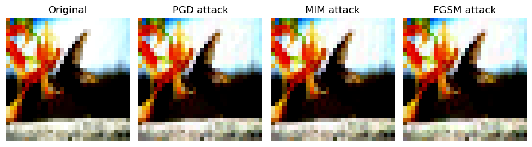

```
Clipping input data to the valid range for imshow with RGB data ([0..1] for floats or [0..255] for integers).
Clipping input data to the valid range for imshow with RGB data ([0..1] for floats or [0..255] for integers).
Clipping input data to the valid range for imshow with RGB data ([0..1] for floats or [0..255] for integers).
Clipping input data to the valid range for imshow with RGB data ([0..1] for floats or [0..255] for integers).
```

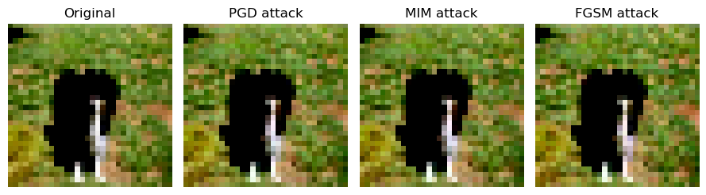

```
Clipping input data to the valid range for imshow with RGB data ([0..1] for floats or [0..255] for integers).
Clipping input data to the valid range for imshow with RGB data ([0..1] for floats or [0..255] for integers).
```

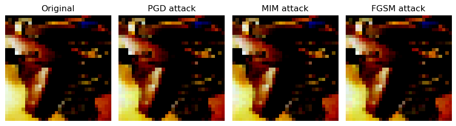

```
Clipping input data to the valid range for imshow with RGB data ([0..1] for floats or [0..255] for integers).
```

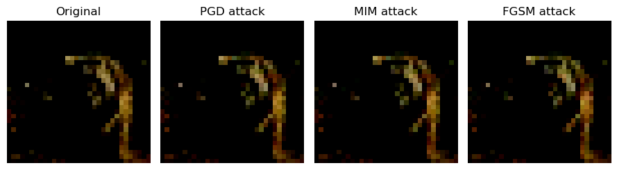

```
Clipping input data to the valid range for imshow with RGB data ([0..1] for floats or [0..255] for integers).
```

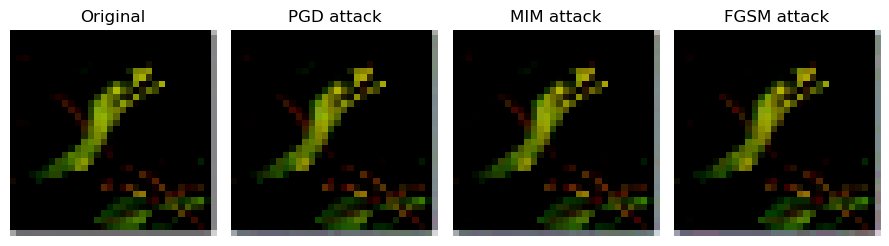

```
Clipping input data to the valid range for imshow with RGB data ([0..1] for floats or [0..255] for integers).
```

[figure not shown]

```
Clipping input data to the valid range for imshow with RGB data ([0..1] for floats or [0..255] for integers).
```

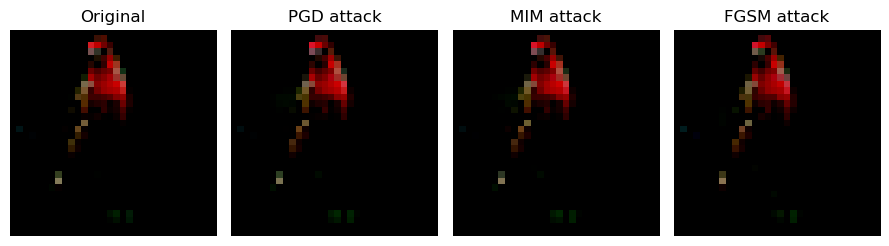

```
Clipping input data to the valid range for imshow with RGB data ([0..1] for floats or [0..255] for integers).
Clipping input data to the valid range for imshow with RGB data ([0..1] for floats or [0..255] for integers).
Clipping input data to the valid range for imshow with RGB data ([0..1] for floats or [0..255] for integers).
Clipping input data to the valid range for imshow with RGB data ([0..1] for floats or [0..255] for integers).
```

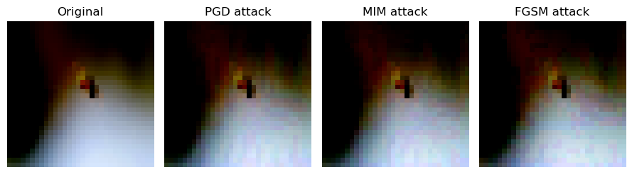

```
Clipping input data to the valid range for imshow with RGB data ([0..1] for floats or [0..255] for integers).
Clipping input data to the valid range for imshow with RGB data ([0..1] for floats or [0..255] for integers).
Clipping input data to the valid range for imshow with RGB data ([0..1] for floats or [0..255] for integers).
Clipping input data to the valid range for imshow with RGB data ([0..1] for floats or [0..255] for integers).
```

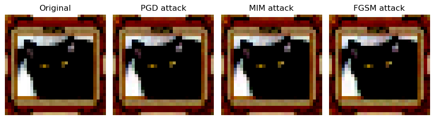

```
Clipping input data to the valid range for imshow with RGB data ([0..1] for floats or [0..255] for integers).
```

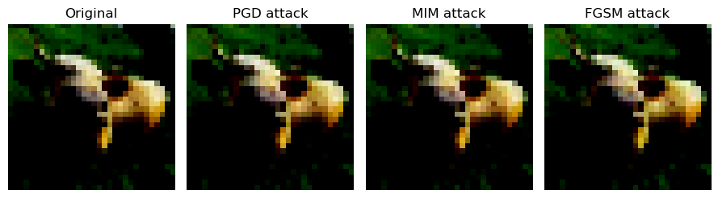

```
Clipping input data to the valid range for imshow with RGB data ([0..1] for floats or [0..255] for integers).
```

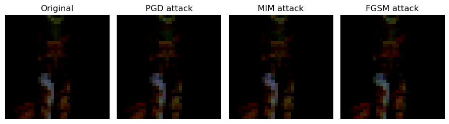

```
Clipping input data to the valid range for imshow with RGB data ([0..1] for floats or [0..255] for integers).
Clipping input data to the valid range for imshow with RGB data ([0..1] for floats or [0..255] for integers).
Clipping input data to the valid range for imshow with RGB data ([0..1] for floats or [0..255] for integers).
```

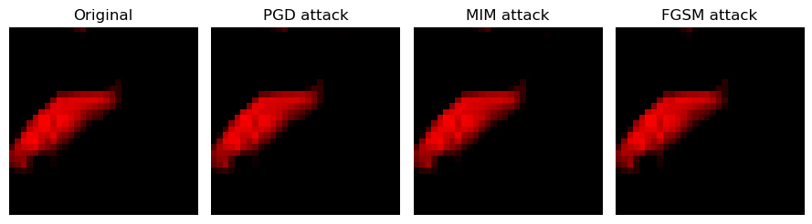

```
Clipping input data to the valid range for imshow with RGB data ([0..1] for floats or [0..255] for integers).
Clipping input data to the valid range for imshow with RGB data ([0..1] for floats or [0..255] for integers).
Clipping input data to the valid range for imshow with RGB data ([0..1] for floats or [0..255] for integers).
Clipping input data to the valid range for imshow with RGB data ([0..1] for floats or [0..255] for integers).
```

[8 more figures not shown]

```
Accuracy for pgd attack:  0.15
Accuracy for mim attack:  0.2
Accuracy for fgsm attack:  0.3
```

```python
# prediction counter / sum for different attack
correct_prediction_pgd = 0
correct_prediction_mim = 0
correct_prediction_fgsm = 0

# choose 20 samples from test cases
random_indices = np.random.choice(data_manager.X_test.shape[0], size=20, replace=False)
x = data_manager.X_test[random_indices]
y = data_manager.y_test[random_indices]

# original prediction without any adversarial attack
x_ori = best_model.predict(x)

# data for each adversarial attack
x_pgd = pgd_attack(best_model.model, tf.cast(x, tf.float32), y, num_steps=20, step_size= 0.002, epsilon = 0.0313,
                   soft_label=False, clip_value_min=0.0, clip_value_max=255.0, from_logits=False)

x_mim = mim_attack(best_model.model, tf.cast(x, tf.float32), y, num_steps=20, step_size= 0.002, epsilon = 0.0313,
                   soft_label=False, clip_value_min=0.0, clip_value_max=255.0, from_logits=False)

x_fgsm = fgsm_attack(best_model.model, tf.cast(x, tf.float32), y, epsilon = 0.0313,
                   soft_label=False, clip_value_min=0.0, clip_value_max=255.0, from_logits=False)

# prediction for each adversarial attack
pgd_pred = best_model.predict(x_pgd)
mim_pred = best_model.predict(x_mim)
fgsm_pred = best_model.predict(x_fgsm)

# plot the original, pgd, mim and fgsm images in their own row for every samples
for j in range(20):
    f, ax = plt.subplots(nrows=1, ncols=4, figsize=(9, 4))
    ax[0].set_title("Original", fontsize=12)
    ax[0].imshow(x[j])
    ax[0].axis('off')
    ax[1].set_title("PGD attack", fontsize=12)
    ax[1].imshow(x_pgd[j])
    ax[1].axis('off')
    ax[2].set_title("MIM attack", fontsize=12)
    ax[2].imshow(x_mim[j])
    ax[2].axis('off')
    ax[3].set_title("FGSM attack", fontsize=12)
    ax[3].imshow(x_fgsm[j])
    ax[3].axis('off')
    plt.tight_layout()
    plt.show()

    # increment the counter if the corresponding prediction is the same
    if pgd_pred[j] == x_ori[j]:
        correct_prediction_pgd += 1
    if mim_pred[j] == x_ori[j]:
        correct_prediction_mim += 1
    if fgsm_pred[j] == x_ori[j]:
        correct_prediction_fgsm += 1

print("Accuracy for pgd attack: ", correct_prediction_pgd / 20)
print("Accuracy for mim attack: ", correct_prediction_mim / 20)
print("Accuracy for fgsm attack: ", correct_prediction_fgsm / 20)
```

**Question 3.7** **Train a robust model using adversarial training with PGD ${\epsilon= 0.0313, k=10, \eta= 0.002}$. Write the code for the adversarial training and report the robust accuracies. After finishing the training, you need to store your best robust model in the folder `./models` and load the model to evaluate the robust accuracies for PGD, MIM, and FGSM attacks with $\epsilon= 0.0313, k=20, \eta= 0.002$ on the testing set.**

[4 points]

```python
optimizer = tf.optimizers.Adam(learning_rate=0.001)
loss_obj = tf.nn.sparse_softmax_cross_entropy_with_logits

# metrics to track the different accuracies.
train_loss = tf.metrics.Mean(name='train_loss')
test_acc_clean = tf.metrics.SparseCategoricalAccuracy()
test_acc_pgd = tf.metrics.SparseCategoricalAccuracy()

# training step for adv attack
def train_step_adv(x, x_adv, y):
    with tf.GradientTape() as tape:
        logits = best_model.model(x)
        logits_adv = best_model.model(x_adv)
        loss = (loss_obj(y, logits) + loss_obj(y, logits_adv))/2
        gradients = tape.gradient(loss, best_model.model.trainable_variables)
        optimizer.apply_gradients(zip(gradients, best_model.model.trainable_variables))
    return loss

batch_size = 16
# iteration number based on batch size
iteration_size = data_manager.X_train.shape[0] // batch_size
remainder_size = data_manager.X_train.shape[0] % batch_size


epochs = 10 # number of epochs
for epoch in range(epochs):
    # keras like display of progress
    progress_bar_train = tf.keras.utils.Progbar(data_manager.X_train.shape[0], verbose=1)
    for k in range(iteration_size+1):
        if k == iteration_size:  # last batch with remainder
            x,y = data_manager.next_batch(remainder_size)
        else:
            x,y = data_manager.next_batch(batch_size)

        if k != iteration_size+1 or remainder_size != 0: # skip when the batch_remainder == 0
            # replace clean example with adversarial example by 10-steps projected_gradient_descent for adversarial training
            x_pgd = pgd_attack(best_model.model, tf.cast(x, tf.float32), y, num_steps=10, step_size= 0.002, epsilon = 0.0313,
                       soft_label=False, clip_value_min=0.0, clip_value_max=255.0, from_logits=False)
            loss = train_step_adv(x, x_pgd, y)

            y_pred = best_model.model(x)
            my_test_res = 0
            test_acc_clean(y, y_pred)
            test_acc_pgd(y, best_model.model(x_pgd))
            train_loss(loss)
            progress_bar_train.add(x.shape[0], values=[('loss', train_loss.result()),
                                                       ("acc (%)", test_acc_clean.result() * 100),
                                                    ("pgd (%)", test_acc_pgd.result() * 100)])

    print()
```

```python
# save model
best_model.model.save("models/Part3_Sec3_7_model.h5")
```

```python
from sklearn.metrics import accuracy_score
from tensorflow.keras.models import load_model


# load model
defense_cnn_model = load_model('models/Part3_Sec3_7_model.h5', custom_objects={'ova_loss': ova_loss})

# function to find the next batch of test samples
def next_batch_test(self, batch_size=32):
    idx = data_manager.random.choice(data_manager.X_test.shape[0], batch_size,
                                     replace=batch_size > data_manager.X_test.shape[0])
    return data_manager.X_test[idx], data_manager.y_test[idx]


y_adv_pgd = []
y_true_pgd = []
y_adv_mim = []
y_true_mim = []
y_adv_fgsm = []
y_true_fgsm = []

batch_size = 16

iteration_size = data_manager.X_test.shape[0] // batch_size


# test
for k in range(iteration_size):
    # next batch of test cases
    x,y = next_batch_test(batch_size)

    # input under adversarial attack
    x_pgd = pgd_attack(defense_cnn_model, tf.cast(x, tf.float32), y, num_steps=20, step_size= 0.002, epsilon = 0.0313,
               soft_label=False, clip_value_min=0.0, clip_value_max=255.0, from_logits=False)

    x_mim = mim_attack(defense_cnn_model, tf.cast(x, tf.float32), y, num_steps=20, step_size= 0.002, epsilon = 0.0313,
                   soft_label=False, clip_value_min=0.0, clip_value_max=255.0, from_logits=False)

    x_fgsm = fgsm_attack(defense_cnn_model, tf.cast(x, tf.float32), y, epsilon = 0.0313,
                       soft_label=False, clip_value_min=0.0, clip_value_max=255.0, from_logits=False)

    # pgd
    y_batch_adv_pgd = np.argmax(defense_cnn_model(x_pgd).numpy(), 1)
    y_adv_pgd.append(y_batch_adv_pgd[0].tolist())
    y_true_pgd.append(y[0].tolist())

    # mim
    y_batch_adv_mim = np.argmax(defense_cnn_model(x_mim).numpy(), 1)
    y_adv_mim.append(y_batch_adv_mim[0].tolist())
    y_true_mim.append(y[0].tolist())

    # fgsm
    y_batch_adv_fgsm = np.argmax(defense_cnn_model(x_fgsm).numpy(), 1)
    y_adv_fgsm.append(y_batch_adv_fgsm[0].tolist())
    y_true_fgsm.append(y[0].tolist())


test_adv_acc_pgd = accuracy_score(y_true_pgd, y_adv_pgd)
print("Test adv under pgd attack accuracy:{}".format(test_adv_acc_pgd))
test_adv_acc_mim = accuracy_score(y_true_mim, y_adv_mim)
print("Test adv under mim attack accuracy:{}".format(test_adv_acc_mim))
test_adv_acc_fgsm = accuracy_score(y_true_fgsm, y_adv_fgsm)
print("Test adv under fgsm attack accuracy:{}".format(test_adv_acc_fgsm))
```

```
Test adv under pgd attack accuracy:0.2542372881355932
Test adv under mim attack accuracy:0.2711864406779661
Test adv under fgsm attack accuracy:0.4576271186440678
```

**Question 3.8 (Kaggle competition)**

You can reuse the best model obtained in this assignment or develop new models to evaluate on the **testing set of the FIT5215 Kaggle competion**. However, to gain any points for this question, your testing accuracy must **exceed** the accuracy threshold from a base model developed by us as shown in the leader board of the competition.

The marks for this question are as follows:

- If you are in *top 10%*, you gain *10 points*.
- If you are in *top 20%*, you gain *8 points*.
- If you are in *top 30%*, you gain *6 points*.
- If you *win* our base model, you gain *4 points*.

**Tips and requirements**

- Your **team name** or **member name** using in this Kaggle competion must contain your student ID, which faciliates us in marking this question.
- You can use any deep/machine techniques in this Kaggle competition.
- We apply some slight transformations and add noises to unseen testing images to make the task more challenging. There is a slight shift between training distribution and testing distribution.
- You must submit your code, trained model, and a brief document decribed your method followed a provided template.

END OF PART 3

END OF ASSIGNMENT

GOOD LUCK WITH YOUR ASSIGNMENT 1!